# CS555 R Final Project Notebook

```r
library('tidyverse')
library('reshape2')
library('car')
```

### Research Scenario

We have soccer player dataset of 500 rows. With this research we aim to answer the following questions

#### Research questions

- Is their a relationship between value and wage of the soccer player ?
- How strong is the relationship ?
- Which other factors are associated with player’s wage ?
- How large is the association between each factor and wage ?
- How accurately can we predict wage of the player ?
- Is the relationship linear ?

The goal of the research is to predict wage of the soccer player

## 1. Data Source [link](https://raw.githubusercontent.com/kiat/R-Examples/master/projects/datasets/project-10.csv)

This is the FIFA19 dataset consists of 15 variables such as age, nationality, name, club, jersey number, height, weight, value, wage, reaction, balance, strength etc of a list of 500 soccer players exist in the game who are currently playing in different soccer clubs around the world.

In our analysis we plan to use following variables

- Age (integer): The age of the player.
- Nationality (character): The nationality of the player.
- Overall (integer): The overall rating of the player’s skills and abilities.
- Potential (integer): The potential future rating of the player’s skills and abilities.
- Club (character): The football club the player is currently associated with.
- Value_in_M (double): The market value of the player in millions of dollars.
- Wage_in_K (integer): The weekly wage of the player in thousands of dollars.
- Height_in_Inches (integer): The height of the player in inches.
- Weight_in_lbs (integer): The weight of the player in pounds.
- Reactions (integer): The player’s reaction attribute rating.
- Balance (integer): The player’s balance attribute rating.
- Strength (integer): The player’s strength attribute rating.

```r
data <- read.csv('https://raw.githubusercontent.com/kiat/R-Examples/master/projects/datasets/project-10.csv')
data
```

| ID | Name | Age | Nationality | Overall | Potential | Club | Value_in_M | Wage_in_K | Jersey_Number | Height_in_Inches | Weight_in_lbs | Reactions | Balance | Strength |
| --- | --- | --- | --- | --- | --- | --- | --- | --- | --- | --- | --- | --- | --- | --- |
| 158023 | L. Messi | 31 | Argentina | 94 | 94 | FC Barcelona | 110.5 | 565 | 10 | 67 | 159 | 95 | 95 | 59 |
| 20801 | Cristiano Ronaldo | 33 | Portugal | 94 | 94 | Juventus | 77.0 | 405 | 7 | 74 | 183 | 96 | 70 | 79 |
| 190871 | Neymar Jr | 26 | Brazil | 92 | 93 | Paris Saint-Germain | 118.5 | 290 | 10 | 69 | 150 | 94 | 84 | 49 |
| 193080 | De Gea | 27 | Spain | 91 | 93 | Manchester United | 72.0 | 260 | 1 | 76 | 168 | 90 | 43 | 64 |
| 192985 | K. De Bruyne | 27 | Belgium | 91 | 92 | Manchester City | 102.0 | 355 | 7 | 71 | 154 | 91 | 77 | 75 |
| 183277 | E. Hazard | 27 | Belgium | 91 | 91 | Chelsea | 93.0 | 340 | 10 | 68 | 163 | 90 | 94 | 66 |
| 177003 | L. Modri? | 32 | Croatia | 91 | 91 | Real Madrid | 67.0 | 420 | 10 | 68 | 146 | 90 | 94 | 58 |
| 176580 | L. Su\xe1rez | 31 | Uruguay | 91 | 91 | FC Barcelona | 80.0 | 455 | 9 | 72 | 190 | 92 | 83 | 83 |
| 155862 | Sergio Ramos | 32 | Spain | 91 | 91 | Real Madrid | 51.0 | 380 | 15 | 72 | 181 | 85 | 66 | 83 |
| 200389 | J. Oblak | 25 | Slovenia | 90 | 93 | Atl\xe9tico Madrid | 68.0 | 94 | 1 | 74 | 192 | 86 | 49 | 78 |

[output cut: 490 more lines]

```r
glimpse(data)
```

```
Rows: 500
Columns: 15
$ ID               <int> 158023, 20801, 190871, 193080, 192985, 183277, 177003, 176580, 155862, 200389, 188545, 1…
$ Name             <chr> "L. Messi", "Cristiano Ronaldo", "Neymar Jr", "De Gea", "K. De Bruyne", "E. Hazard", "L.…
$ Age              <int> 31, 33, 26, 27, 27, 27, 32, 31, 32, 25, 29, 28, 32, 32, 27, 24, 24, 27, 26, 26, 29, 31, …
$ Nationality      <chr> "Argentina", "Portugal", "Brazil", "Spain", "Belgium", "Belgium", "Croatia", "Uruguay", …
$ Overall          <int> 94, 94, 92, 91, 91, 91, 91, 91, 91, 90, 90, 90, 90, 90, 89, 89, 89, 89, 89, 89, 89, 89, …
$ Potential        <int> 94, 94, 93, 93, 92, 91, 91, 91, 91, 93, 90, 90, 90, 90, 90, 94, 91, 90, 92, 90, 89, 89, …
$ Club             <chr> "FC Barcelona", "Juventus", "Paris Saint-Germain", "Manchester United", "Manchester City…
$ Value_in_M       <dbl> 110.5, 77.0, 118.5, 72.0, 102.0, 93.0, 67.0, 80.0, 51.0, 68.0, 77.0, 76.5, 44.0, 60.0, 6…
$ Wage_in_K        <int> 565, 405, 290, 260, 355, 340, 420, 455, 380, 94, 205, 355, 125, 285, 225, 205, 205, 145,…
$ Jersey_Number    <int> 10, 7, 10, 1, 7, 10, 10, 9, 15, 1, 9, 8, 10, 21, 13, 21, 9, 7, 22, 1, 5, 21, 1, 10, 3, 1…
$ Height_in_Inches <int> 67, 74, 69, 76, 71, 68, 68, 72, 72, 74, 72, 72, 74, 68, 66, 70, 74, 69, 74, 78, 74, 73, …
$ Weight_in_lbs    <int> 159, 183, 150, 168, 154, 163, 146, 190, 181, 192, 176, 168, 172, 148, 159, 165, 196, 161…
$ Reactions        <int> 95, 96, 94, 90, 91, 90, 90, 92, 85, 86, 90, 89, 85, 90, 93, 86, 91, 90, 85, 84, 87, 91, …
$ Balance          <int> 95, 70, 84, 43, 77, 94, 94, 83, 66, 49, 78, 71, 54, 90, 92, 85, 71, 80, 43, 45, 52, 59, …
$ Strength         <int> 59, 79, 49, 64, 75, 66, 58, 83, 83, 78, 84, 73, 88, 52, 76, 65, 84, 62, 79, 70, 77, 78, …
```

## 2. Data Cleaning

Renaming of the club names with proper names with no special characters is done so that data can be parsed and processed. Rows with incorrect column values are removed like players with no wage.

```r
data$Club[data$Club == "Atl\xe9tico Madrid"] <- "Atletico Madrid"
data$Club[data$Club == "FC Bayern M\xfcnchen"] <- "FC Bayern Munchen"
data$Club[data$Club == "Borussia M\xf6nchengladbach
"] <- "Borussia Monchengladbach"
data$Club[data$Club == "Be?ikta? JK"] <- "Besiktas JK"
data$Club[data$Club == "Fenerbah\xe7e SK"] <- "Fenerbahce SK"
data$Club[data$Club == "Gr\xeamio"] <- "Gremio"
data$Club[data$Club == "AS Saint-\xc9tienne"] <- "AS Saint Etienne"
data$Club[data$Club == "Medipol Ba?ak?ehir FK"] <- "Basaksehir FK"
data$Club[data$Club == "Borussia M\xf6nchengladbach"] <- "Borussia Monchengladbach"
data$Club[data$Club == "1. FC K\xf6ln"] <- "1. FC Koln"
data$Club[data$Club == "Deportivo Alav\xe9s"] <- "Deportivo Alaves"
data$Club[data$Club == "Guangzhou R&F; FC"] <- "Guangzhou City F.C."
data$Club[data$Club == "Atl\xe9tico Mineiro"] <- "Atletico Mineiro"


data <- data[data$Wage_in_K!=0,]
names(data) <- make.names(names(data))

write.csv(data,'clean_data.csv')
```

## 3. Data Analysis

Various statistical methods like **Correlation tests**, **Simple Linear Regression**, **Multiple Linear Regression**, **ANOVA and ANCOVA** are used for analysis

### Correlation test

Check whether value of the player is associated with the his wage ?

```r
attach(data)
view(data)
```

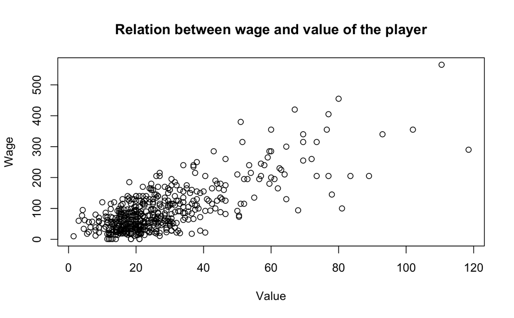

```r
plot( Value_in_M, Wage_in_K, xlab = 'Value', ylab = 'Wage', main = 'Relation between wage and value of the player')
```

```r
cor(Value_in_M, Wage_in_K)
```

```
[1] 0.7531636
```

The correlation coefficient of **0.75** indicates *value* of the player is **strongly** associated with his *wage* and the direction is **positive**.

### 3.1 Simple Least Square Linear Regression

$$\text{wage} = f(\text{value})$$
$$Y_{wage} = \beta_0 + \beta_1 \times
x_{value}$$

```r
# SLR summary
summary(m)
```

```
Call:
lm(formula = Wage_in_K ~ Value_in_M)

Residuals:
     Min       1Q   Median       3Q      Max
-181.579  -32.366   -4.686   27.449  203.132

Coefficients:
            Estimate Std. Error t value Pr(>|t|)
(Intercept)  -1.1410     4.3343  -0.263    0.792
Value_in_M    3.4904     0.1367  25.524   <2e-16 ***
---
Signif. codes:  0 ‘***’ 0.001 ‘**’ 0.01 ‘*’ 0.05 ‘.’ 0.1 ‘ ’ 1

Residual standard error: 50.31 on 497 degrees of freedom
Multiple R-squared:  0.5673,    Adjusted R-squared:  0.5664
F-statistic: 651.5 on 1 and 497 DF,  p-value: < 2.2e-16
```

### - Residual plot analysis

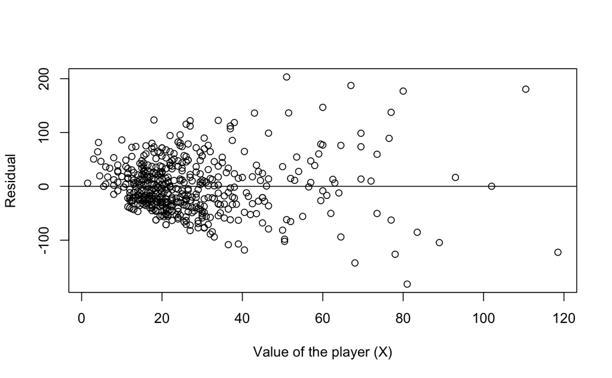

```r
plot(Value_in_M, residuals(m), xlab = 'Value of the player (X)', ylab = 'Residual')
abline(h=0)
```

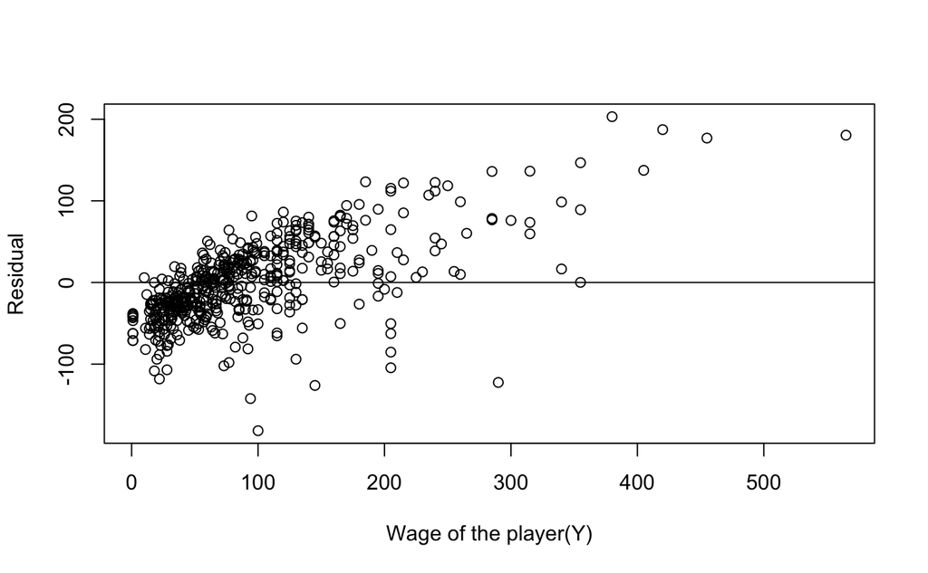

```r
plot(Wage_in_K, residuals(m), xlab = 'Wage of the player(Y)', ylab = 'Residual')
abline(h=0)
```

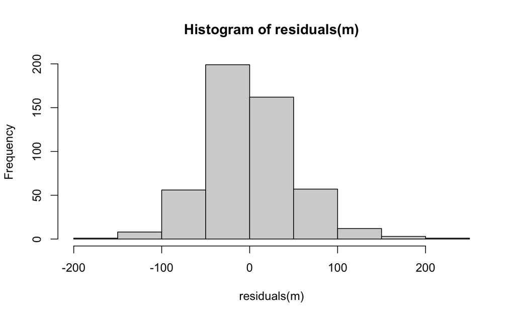

```r
hist(residuals(m))
```

- Clear **obvious pattern** emerges in residual plot.
- As X increase **variability** of outcome increase.
- Residuals are normally distributed.
- It clearly **violates** the linearity and constant variance assumptions. Hence, non-linear relationship exist between the factors Wage and value.

### - Transformation

```r
new.data <- data[Wage_in_K!=0,]
```

#### - Take log of response variable

$$log(Y_{wage}) = \beta_0 + \beta_1
x_{value}$$

```r
cor(new.data$Value_in_M, log(new.data$Wage_in_K))
```

```
[1] 0.5492958
```

```r
m <- lm(log(new.data$Wage_in_K)~new.data$Value_in_M)
summary(m)
```

```
Call:
lm(formula = log(new.data$Wage_in_K) ~ new.data$Value_in_M)

Residuals:
    Min      1Q  Median      3Q     Max
-3.9942 -0.3337  0.1350  0.5066  1.3229

Coefficients:
                    Estimate Std. Error t value Pr(>|t|)
(Intercept)         3.316942   0.069754   47.55   <2e-16 ***
new.data$Value_in_M 0.032251   0.002201   14.65   <2e-16 ***
---
Signif. codes:  0 ‘***’ 0.001 ‘**’ 0.01 ‘*’ 0.05 ‘.’ 0.1 ‘ ’ 1

Residual standard error: 0.8097 on 497 degrees of freedom
Multiple R-squared:  0.3017,    Adjusted R-squared:  0.3003
F-statistic: 214.8 on 1 and 497 DF,  p-value: < 2.2e-16
```

Strength of linear relationship (correlation) decreases to 0.54. R2 of model 0.30

#### - Take square root of response variable

$$\sqrt{Y_{wage}} = \beta_0 + \beta_1
x_{value}$$

```r
cor(sqrt(data$Wage_in_K), Value_in_M)
```

```
[1] 0.7000824
```

```r
m <- lm(sqrt(data$Wage_in_K)~Value_in_M)
summary(m)
```

```
Call:
lm(formula = sqrt(data$Wage_in_K) ~ Value_in_M)

Residuals:
    Min      1Q  Median      3Q     Max
-7.2844 -1.7142  0.0043  1.8329  6.8443

Coefficients:
            Estimate Std. Error t value Pr(>|t|)
(Intercept) 4.769579   0.224050   21.29   <2e-16 ***
Value_in_M  0.154504   0.007069   21.86   <2e-16 ***
---
Signif. codes:  0 ‘***’ 0.001 ‘**’ 0.01 ‘*’ 0.05 ‘.’ 0.1 ‘ ’ 1

Residual standard error: 2.601 on 497 degrees of freedom
Multiple R-squared:  0.4901,    Adjusted R-squared:  0.4891
F-statistic: 477.7 on 1 and 497 DF,  p-value: < 2.2e-16
```

Correlation is 0.70, R2 is 0.49

#### - Squaring explanatory variable

$$Y_{wage} = \beta_0 + \beta_1
x_{value}^2$$

```r
cor(Wage_in_K, Value_in_M**2)
```

```
[1] 0.7248201
```

```r
m <- lm(Wage_in_K~Value_in_M**2)
summary(m)
```

```
Call:
lm(formula = Wage_in_K ~ Value_in_M^2)

Residuals:
     Min       1Q   Median       3Q      Max
-181.579  -32.366   -4.686   27.449  203.132

Coefficients:
            Estimate Std. Error t value Pr(>|t|)
(Intercept)  -1.1410     4.3343  -0.263    0.792
Value_in_M    3.4904     0.1367  25.524   <2e-16 ***
---
Signif. codes:  0 ‘***’ 0.001 ‘**’ 0.01 ‘*’ 0.05 ‘.’ 0.1 ‘ ’ 1

Residual standard error: 50.31 on 497 degrees of freedom
Multiple R-squared:  0.5673,    Adjusted R-squared:  0.5664
F-statistic: 651.5 on 1 and 497 DF,  p-value: < 2.2e-16
```

#### - Log of explanatory variable

$$Y_{wage} = \beta_0 + log_(\beta_1
x_{value})$$

```r
new.data <- data[Value_in_M!=0,]
cor(new.data$Wage_in_K, log(new.data$Value_in_M))
```

```
[1] 0.6569803
```

```r
m <- lm(new.data$Wage_in_K~log(new.data$Value_in_M))
summary(m)
```

```
Call:
lm(formula = new.data$Wage_in_K ~ log(new.data$Value_in_M))

Residuals:
    Min      1Q  Median      3Q     Max
-121.87  -39.25   -8.77   29.12  329.60

Coefficients:
                         Estimate Std. Error t value Pr(>|t|)
(Intercept)              -193.683     15.000  -12.91   <2e-16 ***
log(new.data$Value_in_M)   91.197      4.694   19.43   <2e-16 ***
---
Signif. codes:  0 ‘***’ 0.001 ‘**’ 0.01 ‘*’ 0.05 ‘.’ 0.1 ‘ ’ 1

Residual standard error: 57.66 on 497 degrees of freedom
Multiple R-squared:  0.4316,    Adjusted R-squared:  0.4305
F-statistic: 377.4 on 1 and 497 DF,  p-value: < 2.2e-16
```

Correlation is 0.66 and R2 of model is 0.43

#### - Polynomial regression

$$Y_{wage} = \beta_0 + \beta_1 x_{value} +
\beta_2 x_{value}^2$$

```r
m <- lm(Wage_in_K ~ Value_in_M + I(Value_in_M**2))
summary(m)
```

```
Call:
lm(formula = Wage_in_K ~ Value_in_M + I(Value_in_M^2))

Residuals:
     Min       1Q   Median       3Q      Max
-186.498  -30.620   -5.171   27.378  205.874

Coefficients:
                Estimate Std. Error t value Pr(>|t|)
(Intercept)     6.514653   7.608037   0.856    0.392
Value_in_M      2.997326   0.425343   7.047 6.16e-12 ***
I(Value_in_M^2) 0.005670   0.004632   1.224    0.222
---
Signif. codes:  0 ‘***’ 0.001 ‘**’ 0.01 ‘*’ 0.05 ‘.’ 0.1 ‘ ’ 1

Residual standard error: 50.29 on 496 degrees of freedom
Multiple R-squared:  0.5686,    Adjusted R-squared:  0.5668
F-statistic: 326.8 on 2 and 496 DF,  p-value: < 2.2e-16
```

- Model is significant but **R2** is same and the coefficient of newly added quadratic term is insignificant, by t-test.
- By doing **transformations**, we saw that the **correlation** between Wage and Value of the player **reduces** which in turn **drops** linear model’s performance. Even with the transformations we don’t have sufficient evidence of linear relationship between wage and value of the player, their may be other factors that cause variation in wage.

### - Corelation Matrix

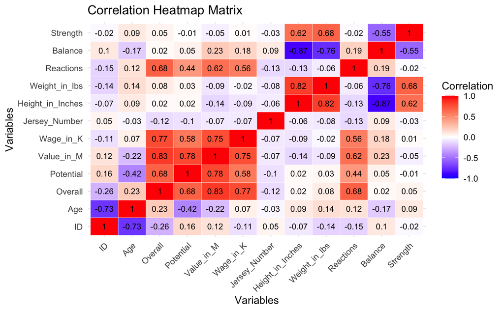

```r
numeric_cols <- data %>% select_if(is.numeric)

cor_matrix <- cor(numeric_cols)
cor_matrix_melted <- melt(cor_matrix)
ggplot(cor_matrix_melted, aes(Var1, Var2, fill = value, label = round(value, 2))) +
  geom_tile(color = "white") +
  geom_text(size = 3, color = "black") +  # Add text labels for correlation coefficients
  scale_fill_gradient2(low = "blue", high = "red", mid = "white",
                       midpoint = 0, limit = c(-1, 1),
                       space = "Lab", name = "Correlation") +
  theme_minimal() +
  theme(axis.text.x = element_text(angle = 45, hjust = 1)) +
  labs(title = "Correlation Heatmap Matrix", x = "Variables", y = "Variables")
```

- From the above plot we can see that *Overall score* and *Value* variables have strong association with the *wage* of the player.
- *Reactions*,*Potential* variables are moderately associated.
- While the *Balance*, *Strength* and *Age* are weakly associated.

### 3.2 Multiple Linear Regression

```r
summary(mlr.m2)
```

```
Call:
lm(formula = Wage_in_K ~ Value_in_M + Overall + Balance + Strength,
    data = data)

Residuals:
     Min       1Q   Median       3Q      Max
-151.935  -28.970   -2.351   29.053  182.708

Coefficients:
              Estimate Std. Error t value Pr(>|t|)
(Intercept) -1254.9040   118.9695 -10.548  < 2e-16 ***
Value_in_M      1.3493     0.2416   5.585 3.87e-08 ***
Overall        14.7718     1.4419  10.245  < 2e-16 ***
Balance         0.7077     0.1629   4.344 1.70e-05 ***
Strength        0.5477     0.2078   2.636  0.00866 **
---
Signif. codes:  0 ‘***’ 0.001 ‘**’ 0.01 ‘*’ 0.05 ‘.’ 0.1 ‘ ’ 1

Residual standard error: 45.56 on 494 degrees of freedom
Multiple R-squared:  0.6472,    Adjusted R-squared:  0.6444
F-statistic: 226.6 on 4 and 494 DF,  p-value: < 2.2e-16
```

#### MLR Model Summary

[output not shown]

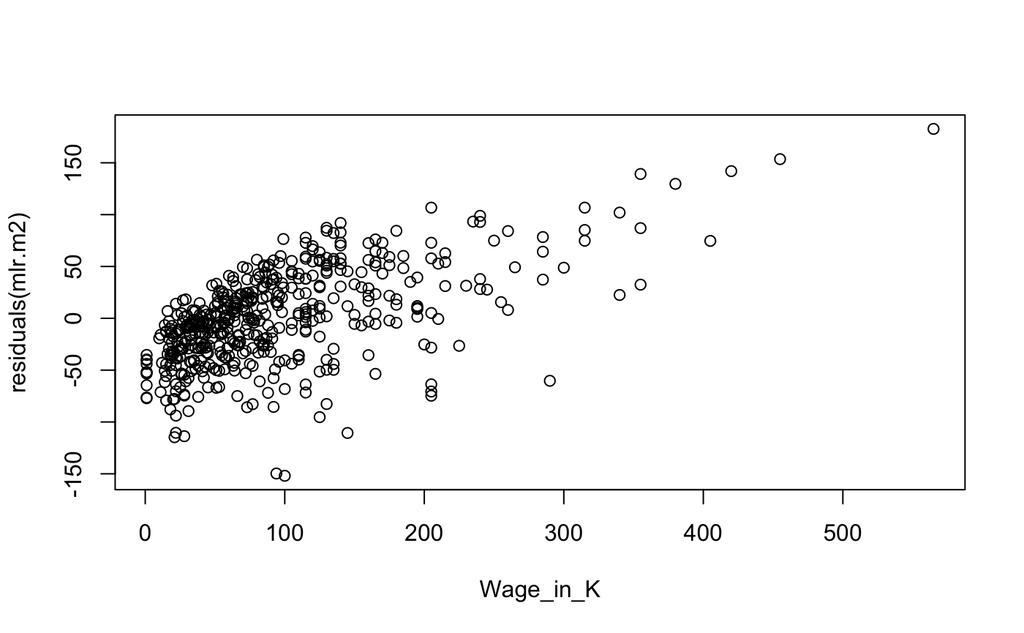

```r
plot(Wage_in_K, residuals(mlr.m2))
```

### - Adding group variable `Club`

```r
length(unique(Club))
```

```
[1] 91
```

```r
length(unique(Nationality))
```

```
[1] 59
```

### - Distribution of Wage across Clubs

**Select top 20 Clubs with highest mean wage**

```r
# get top 20 clubs by highest mean wage
data %>% group_by(Club) %>% summarise(Mean_Wage = mean(Wage_in_K)) %>% arrange(desc(Mean_Wage)) %>% select(Club) %>% head(20) -> top.clubs

data %>% filter(Club %in% top.clubs$Club) -> top.clubs.data
```

[figure not shown]

```r
options(repr.plot.width = 100, repr.plot.height = 6)
ggplot(data=top.clubs.data, aes(x=Club, y=Wage_in_K)) +
  geom_boxplot()+
  labs(x = "Clubs", y = "Wage (in K)", title = 'Distribution of Wage across Clubs')
```

Club with the mean highest wage is *Real Madrid* followed by FC Barcelona and Manchester City.

### - Does a player’s wage differ across soccer clubs ?

#### ANOVA Test

$$\text{wage} = f(\text{club})$$

```r
m <- aov(Wage_in_K ~ Club, data=data)

summary(m)
```

```
             Df  Sum Sq Mean Sq F value Pr(>F)
Club         90 1962560   21806   9.419 <2e-16 ***
Residuals   408  944569    2315
---
Signif. codes:  0 ‘***’ 0.001 ‘**’ 0.01 ‘*’ 0.05 ‘.’ 0.1 ‘ ’ 1
```

As p-value of *Club* in anova model << 0.05. we have significant evidence that wage of the player **varies** by Clubs they play for. Therefore wages change depending on the different Clubs.

```r
# pairwise t-test using bonferroni method
pairwise.t.test(Wage_in_K, Club, data=data,p.adj='bonferroni')
```

[output not shown]

[output cut: 144 more lines]

[output not shown]

```r
# tukeys pair wise t-test
tukey_result <- TukeyHSD(m)
# convert to dataframe
comparisons <- as.data.frame(tukey_result$Club)
# filter pairs whose p-value<0.05
comparisons %>% filter(comparisons$`p adj`<0.05) %>% select('p adj') -> diff.groups

diff.groups
```

|  | p adj |
| --- | --- |
| Real Madrid-1. FC Koln | 2.511295e-02 |
| Arsenal-Ajax | 1.834884e-03 |
| Chelsea-Ajax | 6.883590e-06 |
| FC Barcelona-Ajax | 0.000000e+00 |
| FC Bayern Munchen-Ajax | 7.799390e-03 |
| Juventus-Ajax | 1.197057e-06 |
| Liverpool-Ajax | 4.626332e-04 |
| Manchester City-Ajax | 2.133285e-10 |
| Manchester United-Ajax | 2.821493e-06 |
| Paris Saint-Germain-Ajax | 3.302312e-02 |

[output cut: 270 more lines]

By doing pairwise comparisons using **Tukeys method** the mean wages of the above club combinations are different.  
Out of **4095 pairs**, **280** club pairs are **different**.

### - Does wage differ by clubs after controlling other variables ?

#### ANCOVA Test

$$\text{wage} =
f(\text{value}+\text{overall}+\text{strength}+\text{club})$$

```r
Anova(lm(Wage_in_K ~ Overall+Value_in_M+Balance+Strength+Club, data=data), type=3)
```

```
Anova Table (Type III tests)

Response: Wage_in_K
            Sum Sq  Df F value    Pr(>F)
(Intercept) 111895   1 159.008 < 2.2e-16 ***
Overall     110017   1 156.339 < 2.2e-16 ***
Value_in_M   21610   1  30.709 5.417e-08 ***
Balance      25590   1  36.365 3.696e-09 ***
Strength     10919   1  15.517 9.634e-05 ***
Club        741205  90  11.703 < 2.2e-16 ***
Residuals   284296 404
---
Signif. codes:  0 ‘***’ 0.001 ‘**’ 0.01 ‘*’ 0.05 ‘.’ 0.1 ‘ ’ 1
```

From individual f-test, p-value of *Club* << 0.05. *Club* is a **significant** predictor of a player’s wage after controlling other factors like value, balance, strength and overall.

```r
library(emmeans)
m <- lm(Wage_in_K ~ Overall+Value_in_M+Balance+Strength+Club, data=data)
emmeans.result <- emmeans(m, specs = "Club" , contr = "pairwise",  adjust="tukey")$contrast
emmeans.data <- as.data.frame(emmeans.result)
emmeans.data %>% filter(p.value<0.05) %>% view()
```

```r
m <- lm(Wage_in_K ~ Overall+Value_in_M+Balance+Strength+Club, data=data) #R2=0.875
mean(residuals(m)^2)
```

```
[1] 569.7322
```

```r
m <- lm(Wage_in_K ~ Overall+Value_in_M+Balance+Strength+Potential+Club, data=data) #R2=0.905
mean(residuals(m)^2)
```

```
[1] 448.0136
```

```r
m <- lm(Wage_in_K ~ Overall+Value_in_M+Balance+Strength+Potential+Age+Club, data=data) #R2=0.909
mean(residuals(m)^2)
```

```
[1] 428.7065
```

```r
summary(m)
```

```
Call:
lm(formula = Wage_in_K ~ Overall + Value_in_M + Balance + Strength +
    Potential + Age + Club, data = data)

Residuals:
    Min      1Q  Median      3Q     Max
-82.953  -8.435  -0.075   8.022 133.447

Coefficients:
                                     Estimate Std. Error t value Pr(>|t|)
(Intercept)                        -226.79499  102.51666  -2.212 0.027509 *
Overall                               4.97437    1.68685   2.949 0.003375 **
Value_in_M                            2.36577    0.20829  11.358  < 2e-16 ***
Balance                               0.37235    0.09634   3.865 0.000130 ***
Strength                              0.39790    0.11578   3.437 0.000650 ***
Potential                            -3.89379    0.89247  -4.363 1.63e-05 ***
Age                                   3.30807    0.77747   4.255 2.60e-05 ***
ClubAjax                             -7.98698   24.95396  -0.320 0.749082
ClubAl Hilal                          1.66722   33.07785   0.050 0.959826
ClubAl Nassr                        -14.12328   33.09402  -0.427 0.669781
ClubArsenal                          69.29429   24.22144   2.861 0.004445 **
ClubAS Monaco                        31.09175   26.08366   1.192 0.233964
ClubAS Saint Etienne                -21.19291   32.82916  -0.646 0.518938
ClubAtalanta                        -22.38847   28.58946  -0.783 0.434028
ClubAthletic Club de Bilbao         -15.59350   27.06090  -0.576 0.564777
ClubAtlanta United                  -18.33177   28.54478  -0.642 0.521102
ClubAtletico Madrid                   0.04679   24.02098   0.002 0.998447
ClubAtletico Mineiro                -11.17928   28.60215  -0.391 0.696112
ClubBasaksehir FK                   -23.51314   33.00692  -0.712 0.476649
ClubBayer 04 Leverkusen              28.60606   24.46622   1.169 0.243013
ClubBeijing Sinobo Guoan FC         -32.06810   27.09545  -1.184 0.237301
ClubBesiktas JK                       9.71341   25.73710   0.377 0.706069
ClubBorussia Dortmund                15.51050   24.35438   0.637 0.524574
ClubBorussia Monchengladbach         -5.42049   24.99158  -0.217 0.828402
ClubBurnley                          36.33409   28.44527   1.277 0.202222
ClubChelsea                          78.38260   24.10157   3.252 0.001242 **
ClubCruzeiro                         -6.25390   28.75921  -0.217 0.827962
ClubCrystal Palace                   17.36763   33.02193   0.526 0.599218
ClubDalian YiFang FC                -37.89394   28.48867  -1.330 0.184226
ClubDeportivo Alaves                 10.62677   32.76253   0.324 0.745836
```

[output cut: 58 more lines]

```
ClubTSG 1899 Hoffenheim               3.05104   25.22323   0.121 0.903782
ClubValencia CF                       5.12341   24.25241   0.211 0.832796
ClubVfB Stuttgart                    13.66387   28.58785   0.478 0.632938
ClubVfL Wolfsburg                    19.06694   32.66723   0.584 0.559769
ClubVillarreal CF                   -10.37275   24.97828  -0.415 0.678165
ClubVissel Kobe                     -62.82868   33.21585  -1.892 0.059273 .
ClubWatford                          28.67260   26.95339   1.064 0.288065
ClubWest Ham United                  50.16595   25.20006   1.991 0.047190 *
ClubWolverhampton Wanderers          35.56372   26.93272   1.320 0.187431
---
Signif. codes:  0 ‘***’ 0.001 ‘**’ 0.01 ‘*’ 0.05 ‘.’ 0.1 ‘ ’ 1

Residual standard error: 23.07 on 402 degrees of freedom
Multiple R-squared:  0.9264,    Adjusted R-squared:  0.9088
F-statistic: 52.72 on 96 and 402 DF,  p-value: < 2.2e-16
```

|  | Model | Adjusted R2 | Global Test |
| --- | --- | --- | --- |
| 1. | $$Y_{wage} = \beta_0+\beta_1 x_{overall}+\beta_2 x_{value}+\beta_3 x_{balance}+\beta_4 x_{strength}+\beta_5 x_{club}$$ | \(0.875\) | Significant |
| 2. | $$Y_{wage} = \beta_0+\beta_1 x_{overall}+\beta_2 x_{value}+\beta_3 x_{balance}+\beta_4 x_{strength}+\beta_5 x_{potential}+\beta_6 x_{club}$$ | \(0.905\) | Significant |
| 3. | $$Y_{wage} = \beta_0+\beta_1 x_{overall}+\beta_2 x_{value}+\beta_3 x_{balance}+\beta_4 x_{strength}+\beta_5 x_{potential}+ +\beta_6 x_{age} + \beta_7 x_{club}$$ | \(0.909\) | Significant |

- From the analysis after including group variable `Club` in the model, it explains much **higher** variability in wage i.e from **65%** to around **87%**.
- By adding other variables, **R2** of the model increases to **0.90**.
- **$Y_{wage} = \beta_0+\beta_1 x_{overall}+\beta_2 x_{value}+\beta_3 x_{balance}+\beta_4 x_{strength}+\beta_5 x_{potential}+ +\beta_6 x_{age} + \beta_7 x_{club}$** is the **best model** as it has highest accuracy.

### - Adding group variable `'Nationality'`

#### - Does wage vary by nationalaity ?

##### ANOVA test

```r
m <- aov(Wage_in_K ~ Nationality, data=data)
summary(m)
```

```
             Df  Sum Sq Mean Sq F value Pr(>F)
Nationality  58  360887    6222   1.075  0.337
Residuals   440 2546243    5787
```

Model is **not** significant as p-value of *nationality* > 0.05. We have significant evidence that wages of player does not vary by their nationality.

### Final model

$$Y_{wage} = \beta_0+\beta_1
x_{overall}+\beta_2 x_{value}+\beta_3 x_{balance}+\beta_4
x_{strength}+\beta_5 x_{potential}+ +\beta_6 x_{age} + \beta_7
x_{club}$$

#### Aceses linear assumption

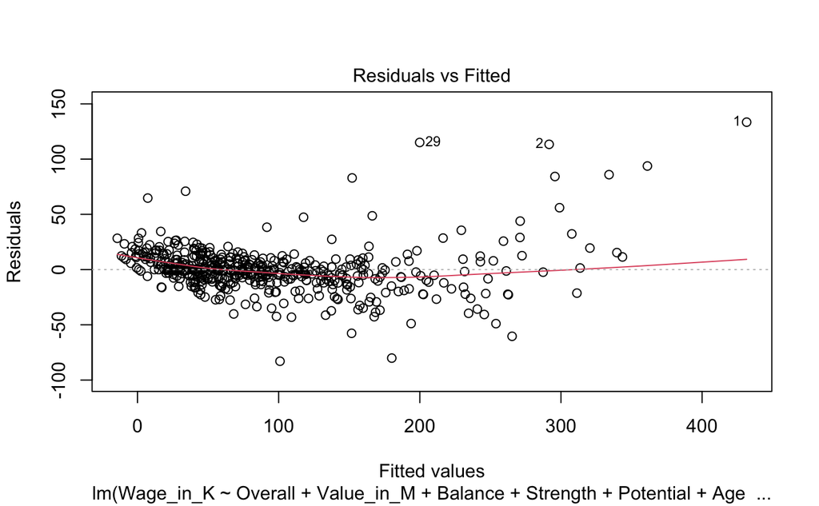

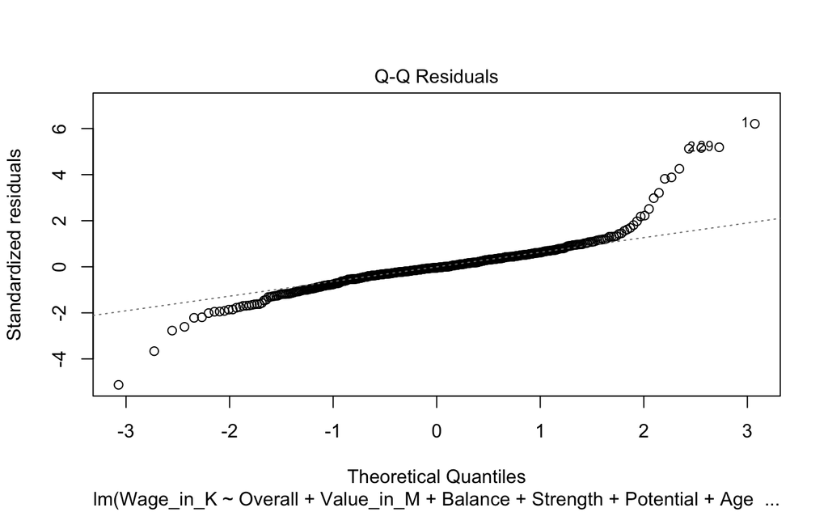

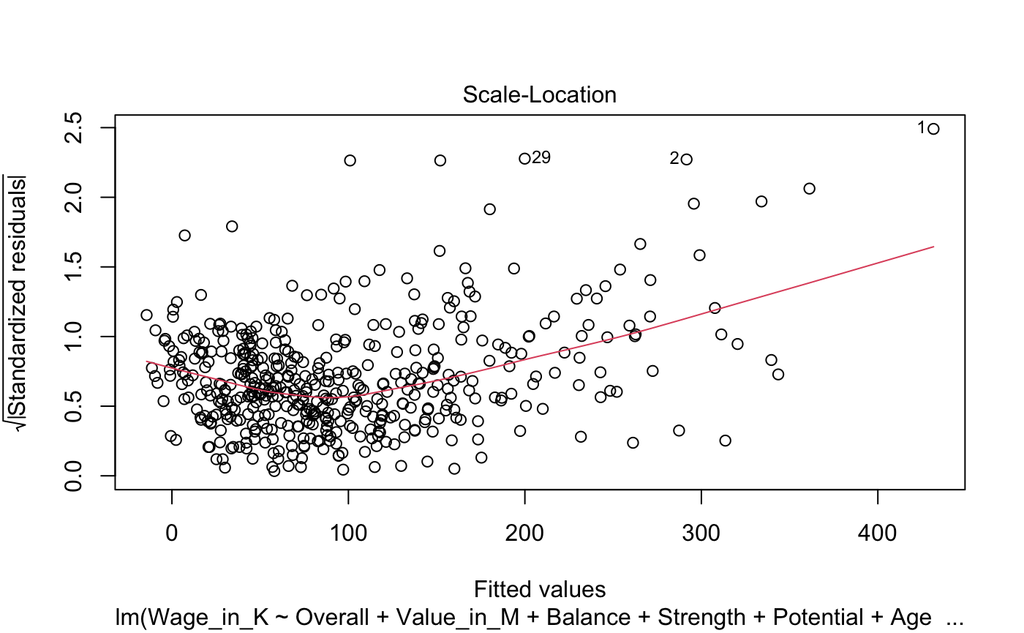

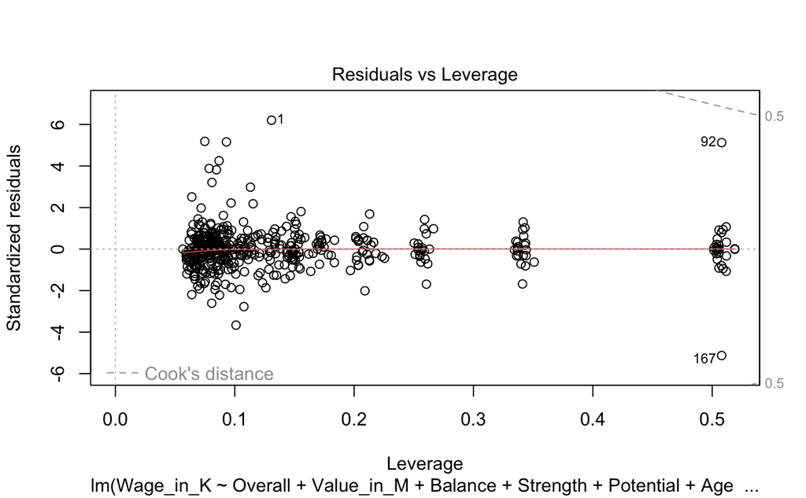

```r
mlr.final = lm(Wage_in_K ~ Overall+Value_in_M+Balance+Strength+Potential+Age+Club, data=data)
plot(mlr.final)
```

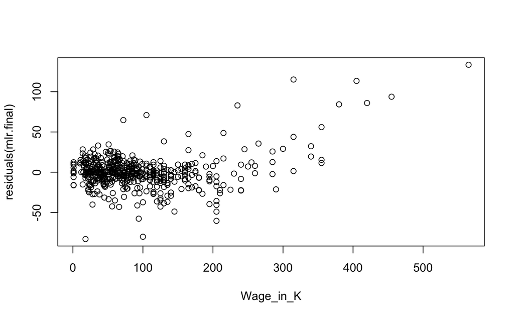

```r
plot(Wage_in_K ,residuals(mlr.final))
```

For extremely high wages ( >400K ), the residual error is very large. Hence could be possible outliers.

### Outlier Removal

[figure not shown]

```r
summary(m)
```

[output not shown]

[output cut: 57 more lines]

[output not shown]

## 3.3 Logistic Regression

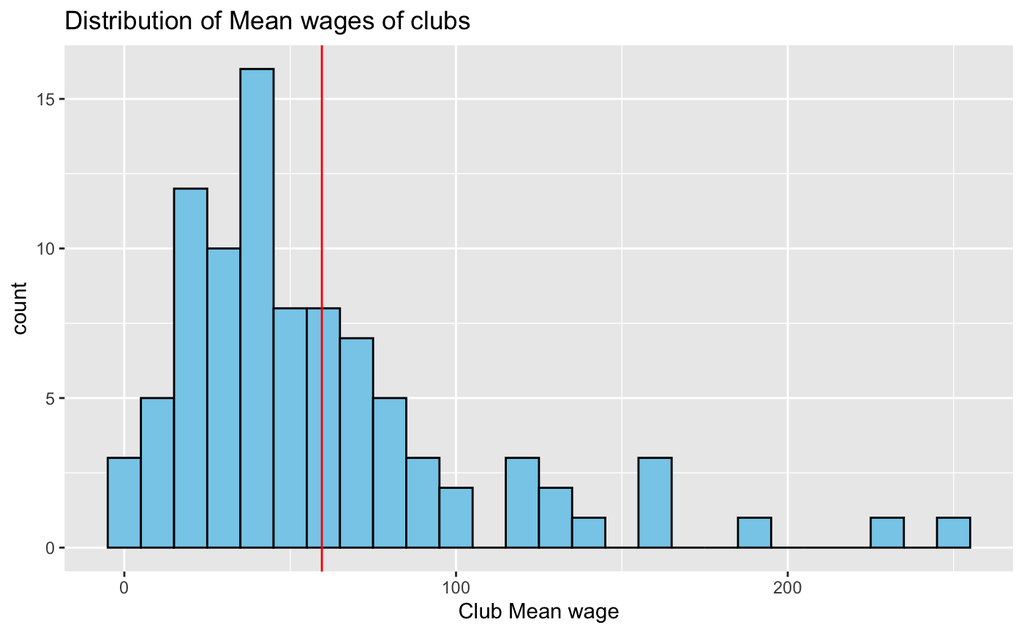

```r
view(data)
data %>% group_by(Club) %>% summarise(Mean_wage = median(Wage_in_K)) %>% view()
data %>% group_by(Club) %>% summarise(Mean_wage = mean(Wage_in_K))  -> tmp

tmp %>% ggplot(aes(x=Mean_wage))+
  geom_histogram(binwidth = 10,fill = "skyblue", color = "black")+
  geom_vline(xintercept = mean(tmp$Mean_wage), color='red')+
  labs(title = 'Distribution of Mean wages of clubs', x='Club Mean wage')
```

Right Skewed distribution Most of the clubs have very low wages, while very few clubs have significantly high wages

```r
data$High_Wage <- ifelse(Wage_in_K > mean(tmp$Mean_wage), 1, 0)
attach(data)
m <- glm(High_Wage ~ Value_in_M, family = binomial)
summary(m)
```

```
Call:
glm(formula = High_Wage ~ Value_in_M, family = binomial)

Coefficients:
            Estimate Std. Error z value Pr(>|z|)
(Intercept) -2.13415    0.29912  -7.135  9.7e-13 ***
Value_in_M   0.10737    0.01307   8.213  < 2e-16 ***
---
Signif. codes:  0 ‘***’ 0.001 ‘**’ 0.01 ‘*’ 0.05 ‘.’ 0.1 ‘ ’ 1

(Dispersion parameter for binomial family taken to be 1)

    Null deviance: 671.99  on 498  degrees of freedom
Residual deviance: 547.28  on 497  degrees of freedom
AIC: 551.28

Number of Fisher Scoring iterations: 5
```

## Conclusion

**Wage** of soccer player depends on **value, overall rating, balance rating, potential, strength rating, age and club**. Given these factors are known, wage of a player could be calculated with **90%** accuracy.

Although model explains 90% of wage, its linear assumptions may **not** be met since their is increasing variance of residuals with higher fitted values.